# Bootstrapping Introduction (Section 3.3-3.4)

Day 11

Claire Kelling

Carleton College  
STAT 120 - Fall 2026

## Question of the Day

Did you have a favorite hiding place as a kid?

## Today’s Topics

Logistics:

- Short report due tonight!
- Check out video on Slack!

Today’s Topic:

- Bootstrapping Intro (Sections 3.3-3.4)
- CIs with Bootstrapping Standard Error
- Bootstrapping with Statkey

## A Note: Confidence Interval about a Proportion

We are 95% sure/confident that the population proportion, or the percent of all US adults who XYZ, falls between 35% and 45%.

- Notice that the word average is not used in this sentence

**Bootstrapping! (Sections 3.3-3.4)**

# Bootstrapping

## Goal of Bootstrapping

- Use a bootstrap distribution to **estimate the SE of our sample statistic** using *only one sample*.
- Use this SE to compute a **confidence interval** for an unknown parameter.

## Bootstrap Steps

1. Generate a **bootstrap sample**

**Definition**

**Bootstrap Sample:** Sample with replacement from the original sample, using the same sample size.

## Bootstrap Sample

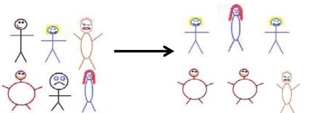

Original Sample Bootstrap Sample

## Bootstrap Sample: Example

Your original sample has data values

18, 19, 19, 20, 21

Which (if any) of the following are possible bootstrap samples?

1. 18, 19, 20, 21, 22
2. 18, 19, 20, 21
3. 18, 18, 19, 20, 21

The answer c) is correct.

Why not a)?

- 22 is not a value from the original sample

Why not b)?

- Bootstrap samples must be the same size as the original sample

# Bootstrapping Intro Continued

## Bootstrap Steps

1. Generate a **bootstrap sample**
2. Compute the statistic of interest from your bootstrap sample.

**Definition**

A **bootstrap statistic** is the statistic computed from the bootstrap sample

## Bootstrap Steps

1. Generate a **bootstrap sample**
2. Compute the statistic of interest from your bootstrap sample.
3. Repeat steps (1) -(2) many times. Plot the distribution of all your bootstrap statistics.

**Definition**

- A **bootstrap distribution** is the distribution of many bootstrap statistics.
- The standard deviation of this distribution is called the **bootstrap SE** of the statistic.

## Bootstrapping Process

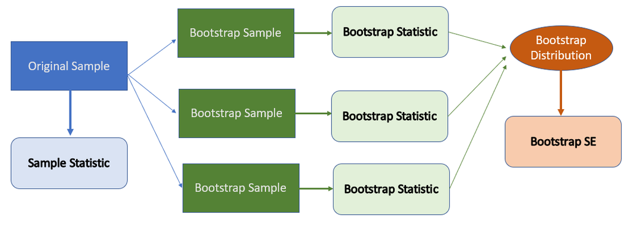

## Why bootstrapping?

- **Ideally:** sample repeatedly from the population
- **Problem:** we only have one sample
- **Assumption:** population is many many copies of the sample
  1. Create a “population” that is many copies of the sample
  2. Sample repeatedly from that “population”

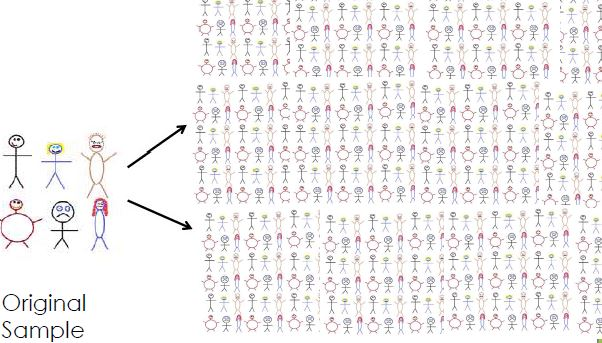

- Bootstrapping through sampling **with replacement** from the original sample approximates this
- As close as we can come to multiple samples from the population (sampling distribution) using one sample

## Sampling vs Bootstrap Distribution

**Sampling Distribution**

- **Process:** Take many samples from the **population**, compute our statistic for each sample
- **Shape**: bell-shaped when n is “large”
- **Center**: population parameter
- **Spread**: called the SE of the statistic

**Bootstrap Distribution**

- **Process:** Take many bootstrap samples from the **original sample**, compute our statistic for each bootstrap sample
- **Shape**: bell-shaped when n is “large”
- **Center**: original sample statistic!
- **Spread**: called the bootstrap SE of the statistic

**SE of the statistic (from the sampling distribution) and the bootstrap SE should be similar!**

## Bootstrapping Recap

1. Generate a **bootstrap sample**
2. Compute the statistic of interest for your bootstrap sample.
3. Repeat steps (1) -(2) many times. Plot the distribution of all your bootstrap statistics.

## Comparing Distributions: Carleton Mission

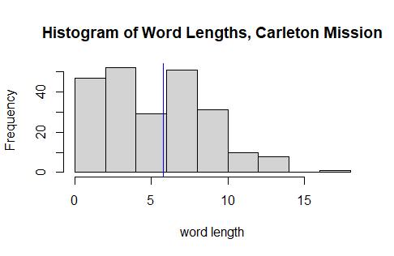

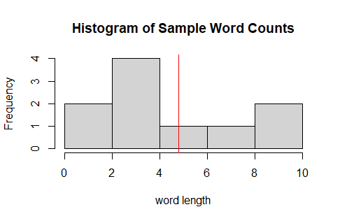

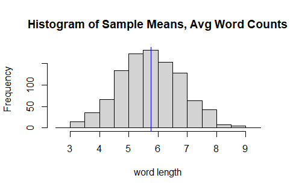

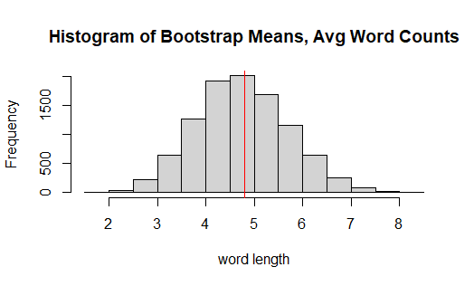

Distribution of population values, distribution of sample values, sampling distribution, bootstrap distribution

# Bootstrap CIs, SE

## Example: Atlanta Commutes

- Random sample of 500 commuters
- Dotplot of the sample data, with sample mean

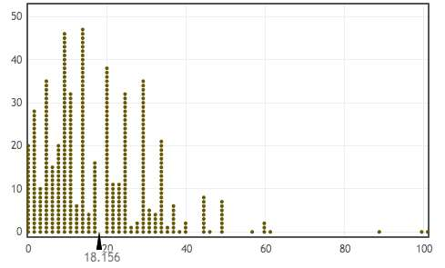

What’s the mean commute distance (miles) for workers in metropolitan Atlanta?

Data: The American Housing Survey (AHS) collected data from Atlanta in 2004

## Example: Atlanta Commutes

Summary Statistics from the sample:

- $n$ = 500
- $\bar{x}$ = 18.16 miles
- $s$ = 13.80 miles

Where might the true $\mu$ be?

- A 95% confidence interval for the true mean: 18.16 $\pm$ 2(SE) but **what is SE??**
- We can bootstrap to find out!!

## Example: Atlanta Commutes

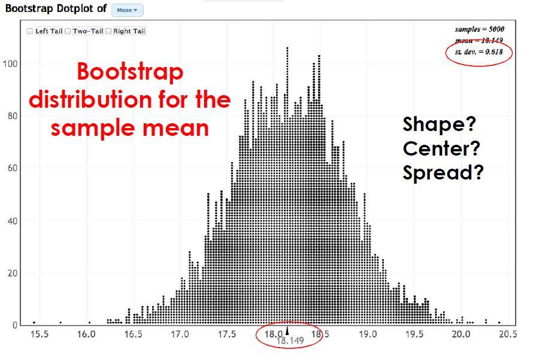

## Example: Atlanta Commutes

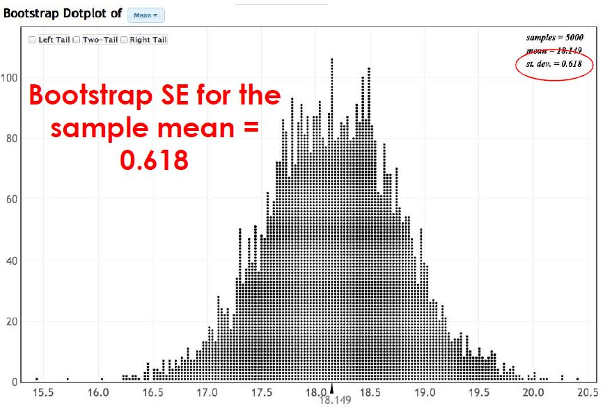

## Example: Atlanta Commutes

Observed Data:

- $n$ = 500
- $\bar{x}$ = 18.16 miles
- $s$ = 13.80 miles

Bootstrapping:

- Bootstrap SE = 0.618 miles
- 95% confidence interval for the average commute distance for Atlantans:

$$18.16 \pm 2 \times 0.618 = (16.92, 19.39)$$

We are 95% confident that the average commute distance for Atlanta commuters is between 16.92 and 19.39 miles.

## Example: Global Warming, Differences

- A survey on 2,251 randomly selected individuals conducted in October 2010 found that 1328 answered “Yes” to the question

  “Is there solid evidence of global warming?”
- Does belief in global warming differ by political party?
- **Data by party:** The sample proportion answering “yes” was 79% among Democrats and 38% among Republicans.
  - (exact numbers for each party were not given, but assume n=1000 for each group)

Give a 95% CI for the **difference in proportions**.

$$p_D - p_R$$

Source: “Wide Partisan Divide Over Global Warming”, Pew Research Center, 10/27/10.

## Example: Global Warming, Differences

1. Calculate the sample statistic: 79% - 38% $=$ 41%
2. Generate bootstrap distribution to estimate the bootstrap SE: 0.02

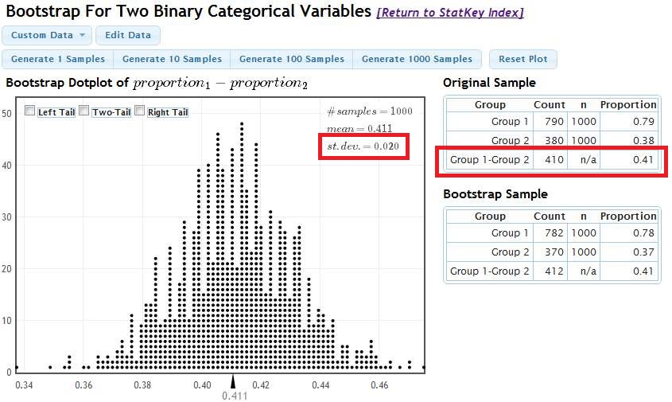

95% CI: 0.41 $\pm$ 2(0.02) = (0.37, 0.45)

Interpretation? We are 95% sure that the percentage of Democrats who believe in global warming is between 37 to 45 %-points higher than the percentage of Republicans.

## Example: Global Warming (2): Differences

Can you conclude with 95% certainty that the proportion of people believing in global warming differs by political party?

1. Yes
2. No

Yes. We are 95% confident that the difference is between 0.37 and 0.45, and this interval does not include 0 (0 would indicate no difference).

## Statkey: Uncertainty Quantification

[figure not shown]

## Statkey: Custom Data

[figure not shown]

[figure not shown]

[figure not shown]

[figure not shown]

## Summary

**Summary**

To generate a bootstrap distribution, we:

1. Generate **bootstrap samples** by sampling *with replacement* from the original sample, using the same sample size
2. Compute the statistic of interest for each of the bootstrap samples, called the **bootstrap statistics**
3. Collect the statistics for many bootstrap samples to form a **bootstrap distribution**
4. Use this to approximate the **sampling distribution**

To create a 95% bootstrap CI:

1. Calculate the statistic for your sample (ex: $\hat{p}, \bar{x}$, etc.)
2. When the distribution is bell-shaped/symmetric, use the SE from the **bootstrap distribution** (not your sample) to create the CI for an unknown parameter (2 $\times$ SE = MOE for 95% CI)

statistic $\pm$ 2 $\times$ SE for 95% CI

## Next Class

Wrapping up Bootstrapping

Let’s practice bootstrapping!